# Exploratory Data Analysis of Hsu et al

Gaja Matassa

Date: April 30, 2025

```r
for (i in 1:length(params))
  print(paste('Parameter:', names(params)[i], ' - Value:', params[[i]], '- Class:', class(params[[i]])))
## [1] "Parameter: InputFolder_WGBS  - Value: ~/DataDir/7.EscapeesExploration/WGBS_Hsu/Output/ - Class: character"
## [1] "Parameter: InputFolder_bACEseq  - Value: ~/DataDir/7.EscapeesExploration/bACEseq_Hsu/Output/ - Class: character"
## [1] "Parameter: OutputFolder  - Value:  - Class: character"
```

```r
InputFolder_WGBS <- params$InputFolder_WGBS
InputFolder_bACEseq <- params$InputFolder_bACEseq

# if (dir.exists(OutputFolder) == FALSE) {
#   dir.create(OutputFolder, recursive=TRUE)
# }
```

From Hsu et al. paper: *A major function of TET1 is the oxidation of 5mC to 5hmC,39 where it can serve as a relatively stable epigenetic mark in non-dividing cells, or as an intermediate for active DNA demethylation. To examine 5hmC enrichment in hPGCLCs, we profiled genome-wide 5hmC levels at single-base resolution using bisulfite-assisted ACEseq (bACEseq).29 By pairing bACEseq with whole genome bisulfite sequencing (WGBS), true 5mC levels and sites can be inferred by subtracting bACEseq signals (5hmC only) from WGBS signals (5mC + 5hmC mixed readout), thereby resolving the epigenetic base ambiguity between 5mC and 5hmC. By profiling ∼40 million (M) common CpG sites between UCLA1 and UCLA2 hESCs and hPGCLCs, we identified a doubling of 5hmC levels in hPGCLCs coupled with a modest reduction of 5mC that can be partially explained by the presence of 5hmC (Figure 2A).*

Therefore I decide for our downstream exploration to create a **bsseq object with genomic loci shared by the two techniques WGBS and bACEseq and shared by UCLA1 and UCLA2 hESCs and hPGCLCs. It will have assays with methylation levels of 5mCs and 5hmCs separated.**

```r
bsseq_obj_WGBS <- readRDS(paste0(InputFolder_WGBS, "bsseq_obj_complete.rds"))
bsseq_obj <- readRDS(paste0(InputFolder_bACEseq, "bsseq_obj_complete.rds"))
```

```r
table(pData(bsseq_obj)$Type)
```

```
##
## D4hPGCLC     hESC  hESC_KO
##        6        4        3
```

```r
table(pData(bsseq_obj_WGBS)$Type)
```

```
##
## D4hPGCLC     hESC  hESC_KO
##        5        5        3
```

```r
bsseq_obj_WGBS <- methylSig::filter_loci_by_group_coverage(
    bs = bsseq_obj_WGBS,
    group_column = 'Type',
    min_samples_per_group = c('D4hPGCLC' = 5, 'hESC' = 5, 'hESC_KO' = 0))
bsseq_obj <- methylSig::filter_loci_by_group_coverage(
    bs = bsseq_obj,
    group_column = 'Type',
    min_samples_per_group = c('D4hPGCLC' = 6, 'hESC' = 4, 'hESC_KO' = 0))
```

```r
#uniqueInbACEseq <- GenomicRanges::setdiff(bsseq_obj, bsseq_obj_WGBS)
hits <- findOverlaps(granges(bsseq_obj_WGBS), granges(bsseq_obj), type = "equal")
bsseq_WGBS_common <- bsseq_obj_WGBS[queryHits(hits), ]
bsseq_bACE_common <- bsseq_obj[subjectHits(hits), ]
```

Between the two techniques it doesn’t seem that we have the exact same samples. In particular, for UCLA1 hESCs only one replicate is shared and for UCLA2 hESCs there is one more replicate for WGBS than for bACEseq. Furthermore, for UCLA1 hPGCLCs there is one more replicate for bACEseq than WGBS. How to deal with it? Exclude the additional UCLA1 hPGCLC replicate and make a fake pairment of UCLA1_hESC_rep2 in WGBS and UCLA1_hESC_rep1 in bACEseq? Or just keep only the shared replicate for UCLA1 hESCs?

```r
rownames(pData(bsseq_WGBS_common))
```

```
##  [1] "UCLA1_hESC_rep2"        "UCLA1_hESC_rep3"        "UCLA1_D4hPGCLC_rep2"
##  [4] "UCLA1_D4hPGCLC_rep3"    "UCLA2_hESC_rep1"        "UCLA2_hESC_rep2"
##  [7] "UCLA2_hESC_rep3"        "UCLA2_D4hPGCLC_rep1"    "UCLA2_D4hPGCLC_rep2"
## [10] "UCLA2_D4hPGCLC_rep3"    "UCLA1_hESC_KO_CDKO1102" "UCLA1_hESC_KO_CDKO1105"
## [13] "UCLA1_hESC_KO_CDKO1312"
```

```r
rownames(pData(bsseq_bACE_common))
```

```
##  [1] "UCLA1_hESC_rep1"        "UCLA1_hESC_rep3"        "UCLA1_D4hPGCLC_rep1"
##  [4] "UCLA1_D4hPGCLC_rep2"    "UCLA1_D4hPGCLC_rep3"    "UCLA2_hESC_rep2"
##  [7] "UCLA2_hESC_rep3"        "UCLA2_D4hPGCLC_rep1"    "UCLA2_D4hPGCLC_rep2"
## [10] "UCLA2_D4hPGCLC_rep3"    "UCLA1_hESC_KO_CDKO1102" "UCLA1_hESC_KO_CDKO1105"
## [13] "UCLA1_hESC_KO_CDKO1312"
```

```r
samples_to_remove <- c("UCLA1_hESC_rep1", "UCLA1_hESC_rep2", "UCLA2_hESC_rep1", "UCLA1_D4hPGCLC_rep1", "UCLA1_hESC_KO_CDKO1102", "UCLA1_hESC_KO_CDKO1105", "UCLA1_hESC_KO_CDKO1312")
bsseq_WGBS <- bsseq_WGBS_common[ , !rownames(pData(bsseq_WGBS_common)) %in% samples_to_remove]
rm(bsseq_WGBS_common)
bsseq_bACE <- bsseq_bACE_common[ , !rownames(pData(bsseq_bACE_common)) %in% samples_to_remove]
rm(bsseq_bACE_common)
```

```r
rownames(pData(bsseq_WGBS))
```

```
## [1] "UCLA1_hESC_rep3"     "UCLA1_D4hPGCLC_rep2" "UCLA1_D4hPGCLC_rep3"
## [4] "UCLA2_hESC_rep2"     "UCLA2_hESC_rep3"     "UCLA2_D4hPGCLC_rep1"
## [7] "UCLA2_D4hPGCLC_rep2" "UCLA2_D4hPGCLC_rep3"
```

```r
rownames(pData(bsseq_bACE))
```

```
## [1] "UCLA1_hESC_rep3"     "UCLA1_D4hPGCLC_rep2" "UCLA1_D4hPGCLC_rep3"
## [4] "UCLA2_hESC_rep2"     "UCLA2_hESC_rep3"     "UCLA2_D4hPGCLC_rep1"
## [7] "UCLA2_D4hPGCLC_rep2" "UCLA2_D4hPGCLC_rep3"
```

Keeping only samples that are shared by both the techniques (without considering the 3 KO hESCs) we go from 10 samples to 8. Let’s proceed with them

```r
granges(bsseq_WGBS)
```

```
## GRanges object with 27815552 ranges and 0 metadata columns:
##                   seqnames    ranges strand
##                      <Rle> <IRanges>  <Rle>
##          [1]          chr1     10468      *
##          [2]          chr1     10470      *
##          [3]          chr1     10483      *
##          [4]          chr1     10488      *
##          [5]          chr1     10492      *
##          ...           ...       ...    ...
##   [27815548] chrKI270757.1     70888      *
##   [27815549] chrKI270757.1     70920      *
##   [27815550] chrKI270757.1     70921      *
##   [27815551] chrKI270757.1     70981      *
##   [27815552] chrKI270757.1     70982      *
##   -------
##   seqinfo: 176 sequences from an unspecified genome; no seqlengths
```

```r
granges(bsseq_bACE)
```

```
## GRanges object with 27815552 ranges and 0 metadata columns:
##                   seqnames    ranges strand
##                      <Rle> <IRanges>  <Rle>
##          [1]          chr1     10468      *
##          [2]          chr1     10470      *
##          [3]          chr1     10483      *
##          [4]          chr1     10488      *
##          [5]          chr1     10492      *
##          ...           ...       ...    ...
##   [27815548] chrKI270757.1     70888      *
##   [27815549] chrKI270757.1     70920      *
##   [27815550] chrKI270757.1     70921      *
##   [27815551] chrKI270757.1     70981      *
##   [27815552] chrKI270757.1     70982      *
##   -------
##   seqinfo: 177 sequences from an unspecified genome; no seqlengths
```

```r
if(!identical(granges(bsseq_WGBS), granges(bsseq_bACE))){
  common_seqs <- intersect(seqlevels(bsseq_obj_WGBS), seqlevels(bsseq_obj))
  seqlevels(bsseq_WGBS, pruning.mode="coarse") <- common_seqs
  seqlevels(bsseq_bACE, pruning.mode="coarse") <- common_seqs}
rm(bsseq_obj_WGBS)
rm(bsseq_obj)
```

```r
if (identical(rownames(pData(bsseq_WGBS)), rownames(pData(bsseq_bACE))) & identical(granges(bsseq_WGBS), granges(bsseq_bACE))) {
  bsseq_complete <- bsseq_WGBS
  names(assays(bsseq_complete)) <- c("M_WGBS", "Cov_WGBS")
  assays(bsseq_complete)$Meth_WGBS <- getMeth(BSseq = bsseq_WGBS, type = "raw")
  names(assays(bsseq_complete)) <- c("M_WGBS", "Cov_WGBS", "Meth_WGBS")
  assays(bsseq_complete)$M_bACEseq <- getCoverage(bsseq_bACE, type = 'M')
  assays(bsseq_complete)$Cov_bACEseq <- getCoverage(bsseq_bACE, type = 'Cov')
  assays(bsseq_complete)$Meth_bACEseq <- getMeth(BSseq = bsseq_bACE, type = "raw")
}
```

```r
assays(bsseq_complete)$Meth_hmC <- assays(bsseq_complete)$Meth_bACEseq
assays(bsseq_complete)$Meth_mC <- assays(bsseq_complete)$Meth_WGBS - assays(bsseq_complete)$Meth_bACEseq

summary(assays(bsseq_complete)$Meth_mC)
```

```
##  UCLA1_hESC_rep3   UCLA1_D4hPGCLC_rep2 UCLA1_D4hPGCLC_rep3 UCLA2_hESC_rep2
##  Min.   :-0.7000   Min.   :-0.8333     Min.   :-0.7500     Min.   :-0.7500
##  1st Qu.: 0.6667   1st Qu.: 0.5556     1st Qu.: 0.5444     1st Qu.: 0.6667
##  Median : 0.8235   Median : 0.7778     Median : 0.7500     Median : 0.8333
##  Mean   : 0.7234   Mean   : 0.6819     Mean   : 0.6579     Mean   : 0.7334
##  3rd Qu.: 0.9231   3rd Qu.: 0.9167     3rd Qu.: 0.8750     3rd Qu.: 0.9412
##  Max.   : 1.0000   Max.   : 1.0000     Max.   : 1.0000     Max.   : 1.0000
##  UCLA2_hESC_rep3   UCLA2_D4hPGCLC_rep1 UCLA2_D4hPGCLC_rep2 UCLA2_D4hPGCLC_rep3
##  Min.   :-0.8000   Min.   :-0.9167     Min.   :-1.0000     Min.   :-0.9091
##  1st Qu.: 0.6807   1st Qu.: 0.5556     1st Qu.: 0.5476     1st Qu.: 0.5561
##  Median : 0.8333   Median : 0.7500     Median : 0.7778     Median : 0.7778
##  Mean   : 0.7302   Mean   : 0.6588     Mean   : 0.6690     Mean   : 0.6708
##  3rd Qu.: 0.9231   3rd Qu.: 0.8750     3rd Qu.: 0.9000     3rd Qu.: 0.9000
##  Max.   : 1.0000   Max.   : 1.0000     Max.   : 1.0000     Max.   : 1.0000
```

```r
#cap values between 0 and 1 (to avoid small negatives)
assays(bsseq_complete)$Meth_mC[assays(bsseq_complete)$Meth_mC < 0] <- 0
assays(bsseq_complete)$Meth_mC[assays(bsseq_complete)$Meth_mC > 1] <- 1

summary(assays(bsseq_complete)$Meth_mC)
```

```
##  UCLA1_hESC_rep3  UCLA1_D4hPGCLC_rep2 UCLA1_D4hPGCLC_rep3 UCLA2_hESC_rep2
##  Min.   :0.0000   Min.   :0.0000      Min.   :0.0000      Min.   :0.0000
##  1st Qu.:0.6667   1st Qu.:0.5556      1st Qu.:0.5444      1st Qu.:0.6667
##  Median :0.8235   Median :0.7778      Median :0.7500      Median :0.8333
##  Mean   :0.7241   Mean   :0.6831      Mean   :0.6588      Mean   :0.7341
##  3rd Qu.:0.9231   3rd Qu.:0.9167      3rd Qu.:0.8750      3rd Qu.:0.9412
##  Max.   :1.0000   Max.   :1.0000      Max.   :1.0000      Max.   :1.0000
##  UCLA2_hESC_rep3  UCLA2_D4hPGCLC_rep1 UCLA2_D4hPGCLC_rep2 UCLA2_D4hPGCLC_rep3
##  Min.   :0.0000   Min.   :0.0000      Min.   :0.0000      Min.   :0.0000
##  1st Qu.:0.6807   1st Qu.:0.5556      1st Qu.:0.5476      1st Qu.:0.5561
##  Median :0.8333   Median :0.7500      Median :0.7778      Median :0.7778
##  Mean   :0.7308   Mean   :0.6598      Mean   :0.6705      Mean   :0.6718
##  3rd Qu.:0.9231   3rd Qu.:0.8750      3rd Qu.:0.9000      3rd Qu.:0.9000
##  Max.   :1.0000   Max.   :1.0000      Max.   :1.0000      Max.   :1.0000
```

Violin plot showing global trend (and mean) of 5mCs + 5hmCs

```
## Subsetting taking random CpGs
```

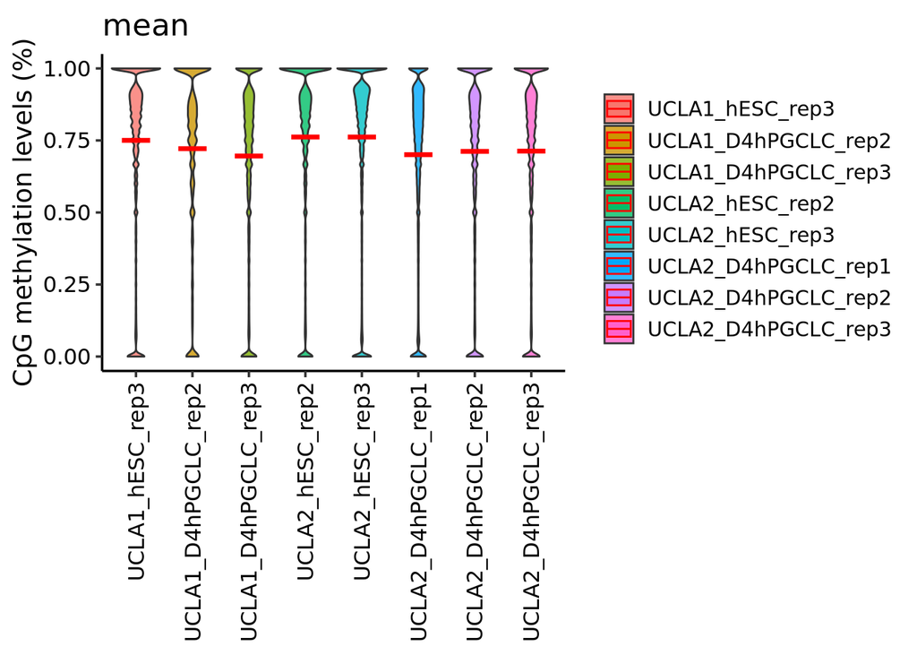

```r
violin_plot(assays(bsseq_complete)$Meth_WGBS, stat="mean", subset = 3000000)
```

Violin plot showing global trend (and mean) of only 5hmCs

```
## Subsetting taking random CpGs
```

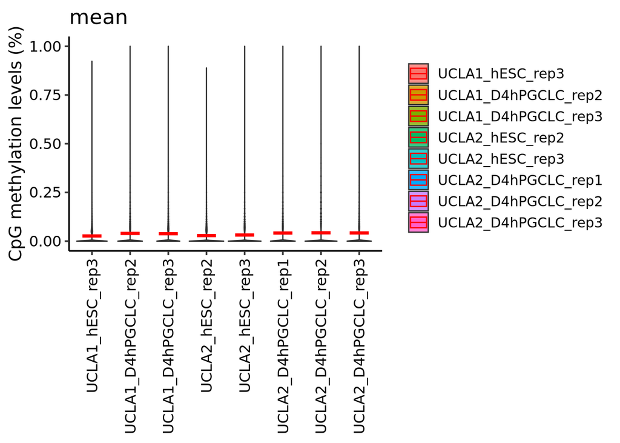

```r
violin_plot(assays(bsseq_complete)$Meth_hmC, stat="mean", subset = 3000000)
```

Violin plot showing global trend (and mean) of only 5mCs

```
## Subsetting taking random CpGs
```

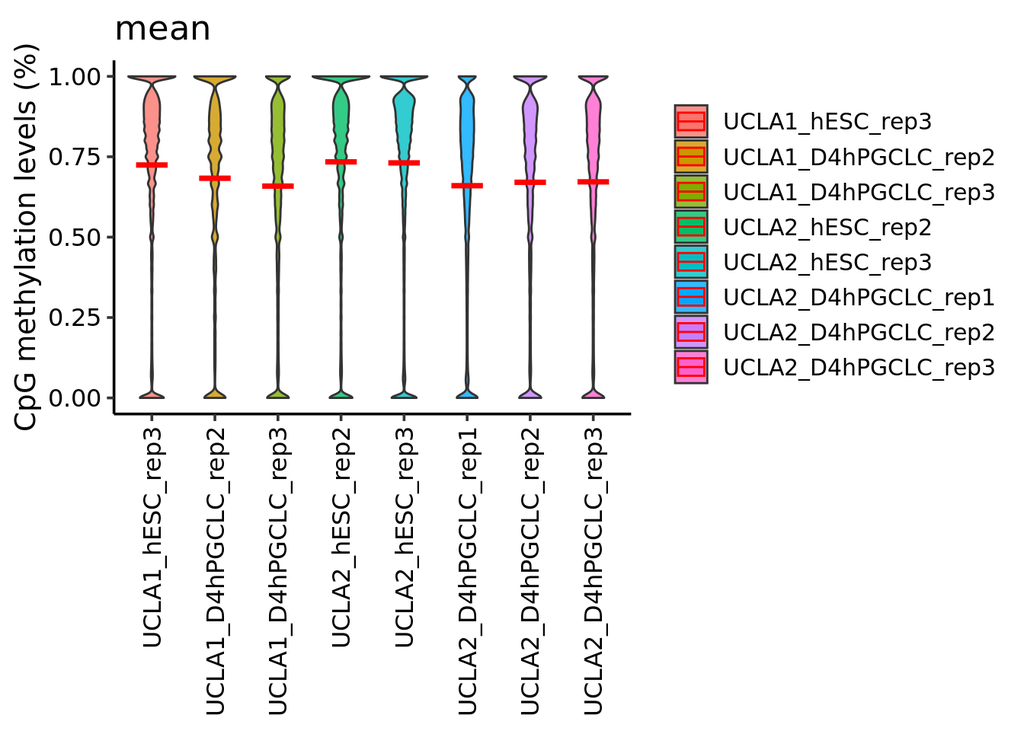

```r
violin_plot(assays(bsseq_complete)$Meth_mC, stat="mean", subset = 3000000)
```

```r
saveRDS(bsseq_complete, "~/DataDir/7.EscapeesExploration/bsseq_Hsu_complete.rds")
saveRDS(bsseq_WGBS, "~/DataDir/7.EscapeesExploration/bsseq_WGBS.rds")
saveRDS(bsseq_bACE, "~/DataDir/7.EscapeesExploration/bsseq_bACE.rds")
```